# Week 9 Clustering Algorithms

## Theory and Practice

### by Ying Lin, Ph.D.

## Overview of the Topics

- Basic concepts of cluster analysis
- KMeans algorithm
- Hierarchical Agglomerative Clustering (HAC)
- Evaluation of the clustering outputs
- Hyperparameters of the clustering algorithms
- Visualize clustering output: PCA (Principal Component Analysis)
- Python demo of the cluster analysis

## Motivations

- Identify grouping structure of data so that objects within the same group are closer (more similar) to each other while farther (less similar) to those in different groups
  - Various distance/proximity functions
  - intra-cluster distance vs. inter-cluster distance
- Unsupervised learning: used for data exploration
  - Can also be adapted for supervised learning purpose
- Types of cluster analysis
  - Partitional vs. Hierarchical: one point can belong to one or multiple clusters
  - kmeans algorithm vs. HAC (Hierarchical Agglomerative Clustering) algorithm

## Partitional vs. Hierarchical Clustering

[figure not shown]

## Major Applications of Cluster Analysis

- Data sampling: use centroid as the representative samples
  - Centroid: center of mass which is caculated as the (arithmetic) mean of all the data points in the same cluster (separately for each dimension)
- Marketing segmentation analysis: help marketers segment their customer bases and develop targeted marketing programs
- Insurance: identify groups of motor insurance policy holders with a higher average claim cost
- Microarray analysis for biomedical research: A high throughput technology which allows testing thousand of genes simultaneously in different disease states

## Distance Functions

- Clustering is based on *distance*. How to measure it?
- Minkowski distance: distance between two vectors is the norm of their difference; $L_p$ norm, $d_{minkowski} = (\sum_{i=1}^n |x_i-y_i|^p)^\frac{1}{p}$
- Manhattan distance: $L_1$ norm $d_{manhattan} = \sum_{i=1}^n |(x_i-y_i)|$
- Euclidean distance: $L_2$ norm $d_{euclidean}(x, y) = \sqrt{\sum_{i = 1}^n (x_i - y_i)^2}$

## Additional Distance Functions

- Cosine Similarity $cos\theta = \frac{\vec{a}\cdot \vec{b}}{\lVert{\vec{a}}\rVert\lVert{\vec{b}\rVert}}$
  - Magnitude of vectors does not matter but the orientation
  - Used often in measuring similarities between different documents, such as text mining and NLP

## Model Preprocessing

- Transformation of categorical attributes into numerical attributes (opposite to association rule mining)
- Data standardization, normalization, rescale
  - Applies to all algorithms based on distance: KNN, SVM, etc.
- Remove or impute missing values
- Detection and removal of noisy data and *outliers*
- Dimension reduction: irrelevant or correlated/redundant attributes

## Animation of How kmeans Algorithm works

[figure not shown]

## Kmeans Clustering with EM Algorithm

- Expectation Maximization (EM) Algorithm
  - e.g. Lloyd/Forgy algorithm
  - Randomly assign k cluster centers (centroids)
  - E-Step: Assign all data points to their closest centroids
  - M-Step: Update centroid assignments to the mean of all data points in the same cluster
    - Mean of the data points minimizes the squared distance between data points and cluster centers or SSE (objective function fo k-means)
    - Derivation
  - Repeat the previous two steps until centroids are stable
- reference
  - https://stats.stackexchange.com/questions/76866/clustering-with-k-means-and-em-how-are-they-related

## Cluster Validity Evaluation

- SSE (Sum of Square Error): most common measure $SSE = \sum_{i=1}^K\sum_{x\in C_i}dist^2(m_i, x)$
  - Cluster cohesion
  - SSE is a monotonically decreasing function of number of clusters. Therefore it can be used to compare cluster performance only for similar number of clusters

## Objective Function for Kmeans Clustering: SSE

- Also known as loss/cost function
- Goal of Kmeans method is to
  - Minimize SSE of within-cluster variance
  - Same as the sum of Euclidean distance between all data points with their respective cluster centroids
- Therefore no needs to set the distance function for Kmeans method

## Hierarchical Agglomerative Clustering

- Treat each data point as a cluster
- Compute the pairwise distance matrix for all clusters
- Merge closer clusters into a larger one and update the distance matrix
- Keep repeating the previous step until there is only one cluster left
- Opposite: HDC (Hierarchical Divisive Clustering)

## Defintion of Inter-Cluster Distance

- Single linkage: minimal pairwise distance between data points belonging to different clusters
- Complete linkage: maximal pairwise distance between data points belonging to different clusters
- Average linkage method: average pairwise distance between all data points belonging to different clusters
- Centroid linkage method: pairwise distance between centroids of different clusters

[figure not shown]

## Model Parameters

- Algorithm-specific
  - kmeans
    - Number of clusters: Elbow method to estimate
    - Initial choice of cluster centers (centroid)
      - Kmeans method is guaranteed to converge but not guaranteed to converge to global optimial
    - Maximal number of repeats
  - Hierarchical clustering
    - Distance function between data points
    - Definition of intercluster distance: single vs. complete vs. average vs. centroid linkage
    - Number of clusters to output (needed after clustering)

## Comparison Between Kmeans and HAC (1)

- Objective function
  - Kmeans: sum of squared difference between data points and their respective centroid (within SS)
  - HAC: no objective function, greedy algorithm
- Parameter setting
  - Kmeans: need to specify number of clusters prior to running aglorithm
  - HAC: no need to choose number of clusters a priori; can choose after fact
- Performance
  - Kmeans: Fast with linear time complexity $O(N)$ ($N$: number of data points)
  - HAC: Slow with quadratic complexity $O(N^2)$
  - Hybrid approach: run Kmeans first to reduce dataset size and then HAC to cluster

## Comparison Between Kmeans and HAC (2)

- Structure of clusters
  - Kmeans: works best with sphere clusters with similar size
  - HAC: works with clusters of different size and shape
    - Depending on inter-cluster distance definition
    - Single-linkage method: clusters of different size; prone to outliers
    - Complete-linkage method: clusters of similar size; prone to outliers
    - Average/Centroid linkage: resist outliers
  - Both methods couldn't deal well with clusters of different densities: DBScan
- Both methods mostly work with numerical attributes only (contrary to association rule mining)

## Mixture Modeling with EM Algorithm

- e.g. GMM (Gaussian Mixture Modeling)
- Basic ideas: group data points into clusters so that each cluster belong to one unique distribution (parameterised). How to estimate such distribution parameters? Use EM and MLE algorithm.
- Steps
  - Expectation: Given a model, what is the likelihood of observing the data points
  - Maximization: Identify models (and parameters) that maximize the likelihood of observing the data points
- How is it related to clustering?
  - both are about grouping the data points
  - Kmeans is hard clustering, ie. each object is assigned to exactly one cluster; the models focus on centroid only without considering covariances or variance
  - GMM is soft partitioning where the models are multivariate Gaussian distribution with probability estimation for each data point

```python
## Import Libraries for Analysis
import pandas as pd
import numpy as np
import matplotlib.pyplot as plt
from sklearn import preprocessing
import seaborn as sns
from scipy.spatial import distance_matrix
from sklearn.cluster import KMeans
```

```python
## Data Preprocessing
USArrest = pd.read_csv("https://forge.scilab.org/index.php/p/rdataset/source/file/master/csv/datasets/USArrests.csv")
USArrest = USArrest.set_index('Unnamed: 0')
USArrest.isnull().sum(axis=0)
min_max_scaler = preprocessing.MinMaxScaler()
np_scaled = min_max_scaler.fit_transform(USArrest)
df_normalized = pd.DataFrame(np_scaled, columns=USArrest.columns, index=USArrest.index)
df_normalized.describe()
```

|  | Murder | Assault | UrbanPop | Rape |
| --- | --- | --- | --- | --- |
| count | 50.000000 | 50.000000 | 50.000000 | 50.000000 |
| mean | 0.420964 | 0.430685 | 0.568475 | 0.360000 |
| std | 0.262380 | 0.285403 | 0.245335 | 0.242025 |
| min | 0.000000 | 0.000000 | 0.000000 | 0.000000 |
| 25% | 0.197289 | 0.219178 | 0.381356 | 0.200904 |
| 50% | 0.388554 | 0.390411 | 0.576271 | 0.330749 |
| 75% | 0.629518 | 0.698630 | 0.775424 | 0.487726 |
| max | 1.000000 | 1.000000 | 1.000000 | 1.000000 |

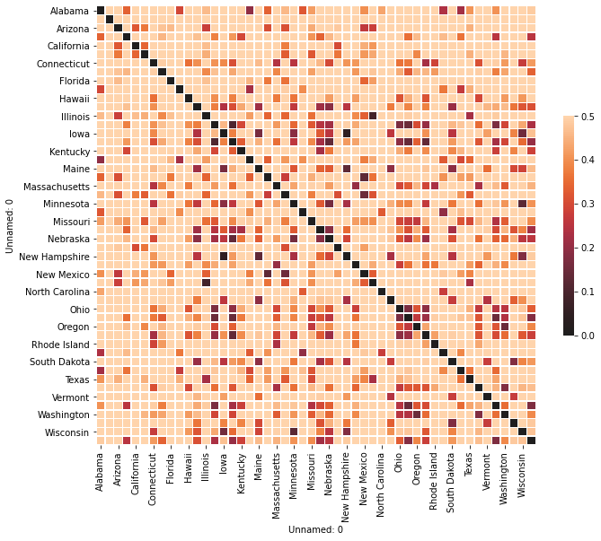

```python
## Visualize the Data
dist_matrix = pd.DataFrame(distance_matrix(df_normalized.values,
                           df_normalized.values, p=2),
                           index=df_normalized.index,
                           columns=df_normalized.index)
f, ax = plt.subplots(figsize=(11, 9))
sns.heatmap(dist_matrix, vmax=.5, center=0, square=True,
            linewidths=.5, cbar_kws={"shrink": .5})
```

```python
## KMeans Clustering using *sklearn*

kmeans = KMeans(n_clusters=2, n_init=25, max_iter=100, random_state=6)
kmeans.fit(df_normalized)
kmeans.__dict__.keys()
kmeans.labels_
```

```
array([1, 1, 1, 0, 1, 1, 0, 0, 1, 1, 0, 0, 1, 0, 0, 0, 0, 1, 0, 1, 0, 1,
       0, 1, 1, 0, 0, 1, 0, 0, 1, 1, 1, 0, 0, 0, 0, 0, 0, 1, 0, 1, 1, 0,
       0, 0, 0, 0, 0, 0])
```

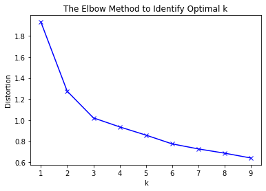

```python
## Elbow Method (Codes)

from scipy.spatial.distance import cdist
distortions = []
K = range(1, 10)
for k in K:
    kmeanModel = KMeans(n_clusters=k).fit(dist_matrix)
    kmeanModel.fit(dist_matrix)
    distortions.append(sum(np.min(cdist(dist_matrix, kmeanModel.cluster_centers_, 'euclidean'), axis=1)) / dist_matrix.shape[0])

plt.plot(K, distortions, 'bx-')
plt.xlabel('k')
plt.ylabel('Distortion')
plt.title('The Elbow Method to Identify Optimal k')
plt.show()
```

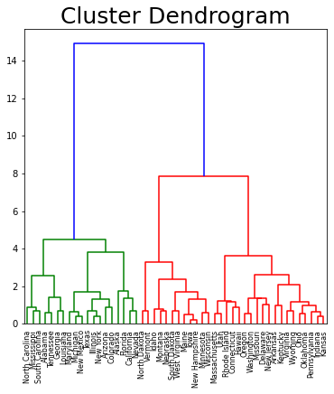

```python
from scipy.cluster.hierarchy import ward, dendrogram

linkage_matrix = ward(dist_matrix)

fig, ax = plt.subplots(figsize=(6, 6))
ax.grid(False)
ax.set_title('Cluster Dendrogram', fontsize = 25)
ax = dendrogram(linkage_matrix, orientation='top', labels=dist_matrix.index)
plt.xticks(fontsize=8)
plt.show()
```

```python
USArrest.head(3)
USArrest.var(axis=0)
USArrest.columns
USArrest.dtypes
from sklearn.cluster import KMeans, AgglomerativeClustering
from sklearn.decomposition import PCA

km_out1 = KMeans(n_clusters=2, random_state=8).fit_predict(USArrest)
km_out2 = KMeans(n_clusters=2, random_state=8).fit_transform(USArrest).argmin(axis=1)
sum(km_out1 != km_out2)

hac_out = AgglomerativeClustering(n_clusters=2).fit_predict(USArrest)
hac_out
dif_ind = np.where(km_out1 != hac_out)

USArrest.index[dif_ind].to_list()
```

| Unnamed: 0 | Murder | Assault | UrbanPop | Rape |
| --- | --- | --- | --- | --- |
| Alabama | 13.2 | 236 | 58 | 21.2 |
| Alaska | 10.0 | 263 | 48 | 44.5 |
| Arizona | 8.1 | 294 | 80 | 31.0 |

```
Murder        18.970465
Assault     6945.165714
UrbanPop     209.518776
Rape          87.729159
dtype: float64
```

```
Index(['Murder', 'Assault', 'UrbanPop', 'Rape'], dtype='object')
```

```
Murder      float64
Assault       int64
UrbanPop      int64
Rape        float64
dtype: object
```

```
0
```

```
array([1, 1, 1, 0, 1, 0, 0, 1, 1, 0, 0, 0, 1, 0, 0, 0, 0, 1, 0, 1, 0, 1,
       0, 1, 0, 0, 0, 1, 0, 0, 1, 1, 1, 0, 0, 0, 0, 0, 0, 1, 0, 0, 0, 0,
       0, 0, 0, 0, 0, 0], dtype=int64)
```

```
['Arkansas', 'Colorado', 'Georgia', 'Tennessee', 'Texas']
```

```python
from sklearn.preprocessing import StandardScaler
USArrest_norm = StandardScaler().fit_transform(USArrest) # It is necessary to normalize data prior to PCA analysis in order to interpret loading matrix
USArrest_norm.mean(axis=0)
USArrest_norm.std(axis=0)
PCA(n_components=4, random_state=8).fit_transform(USArrest_norm).var(axis=0)
pca_obj = PCA(n_components=4, random_state=8).fit(USArrest_norm)
np.sum(pca_obj.components_ ** 2, axis=1) # Loading vector has properties: sum of squares is 1 to control for variance
pd.DataFrame(pca_obj.components_.T, index=USArrest.columns)
# np.sum(pca_obj.components_ ** 2, axis=1)
pca_obj.components_
# ', '.join(dir(pca_obj))
pca_obj.explained_variance_ratio_
```

```
array([-7.10542736e-17,  1.38777878e-16, -4.39648318e-16,  8.59312621e-16])
```

```
array([1., 1., 1., 1.])
```

```
array([2.48024158, 0.98976515, 0.35656318, 0.17343009])
```

```
array([1., 1., 1., 1.])
```

|  | 0 | 1 | 2 | 3 |
| --- | --- | --- | --- | --- |
| Murder | 0.535899 | 0.418181 | -0.341233 | 0.649228 |
| Assault | 0.583184 | 0.187986 | -0.268148 | -0.743407 |
| UrbanPop | 0.278191 | -0.872806 | -0.378016 | 0.133878 |
| Rape | 0.543432 | -0.167319 | 0.817778 | 0.089024 |

```
array([[ 0.53589947,  0.58318363,  0.27819087,  0.54343209],
       [ 0.41818087,  0.1879856 , -0.87280619, -0.16731864],
       [-0.34123273, -0.26814843, -0.37801579,  0.81777791],
       [ 0.6492278 , -0.74340748,  0.13387773,  0.08902432]])
```

```
array([0.62006039, 0.24744129, 0.0891408 , 0.04335752])
```

```python
from sklearn.mixture import GaussianMixture

gmm_out = GaussianMixture(n_components=2, random_state=8).fit_predict(USArrest)
gmm_model = GaussianMixture(n_components=2, random_state=8).fit(USArrest)
gmm_out
gmm_model.predict(USArrest)
gmm_model.predict_proba(USArrest)

np.sum(gmm_out != km_out1)
USArrest.index[np.where(gmm_out != km_out1)]
```

```
array([1, 1, 1, 0, 1, 1, 0, 0, 1, 1, 0, 0, 1, 0, 0, 0, 0, 1, 0, 1, 0, 1,
       0, 1, 0, 0, 0, 1, 0, 0, 1, 1, 1, 0, 0, 0, 0, 0, 0, 1, 0, 1, 1, 0,
       0, 0, 0, 0, 0, 0], dtype=int64)
```

```
array([1, 1, 1, 0, 1, 1, 0, 0, 1, 1, 0, 0, 1, 0, 0, 0, 0, 1, 0, 1, 0, 1,
       0, 1, 0, 0, 0, 1, 0, 0, 1, 1, 1, 0, 0, 0, 0, 0, 0, 1, 0, 1, 1, 0,
       0, 0, 0, 0, 0, 0], dtype=int64)
```

```
array([[4.33683886e-03, 9.95663161e-01],
       [1.60009827e-07, 9.99999840e-01],
       [4.01963761e-03, 9.95980362e-01],
       [9.93819747e-01, 6.18025292e-03],
       [2.01095223e-04, 9.99798905e-01],
       [4.42784954e-03, 9.95572150e-01],
       [1.00000000e+00, 3.52833991e-12],
       [9.97826851e-01, 2.17314869e-03],
       [1.99867862e-03, 9.98001321e-01],
       [1.92412011e-05, 9.99980759e-01],
       [9.99999999e-01, 1.29836144e-09],
       [1.00000000e+00, 1.10821854e-12],
       [2.74498610e-01, 7.25501390e-01],
       [9.99998178e-01, 1.82245724e-06],
       [1.00000000e+00, 2.11785376e-17],
       [9.99999961e-01, 3.85913712e-08],
       [9.99948401e-01, 5.15985875e-05],
       [1.62626172e-04, 9.99837374e-01],
       [1.00000000e+00, 2.23673313e-17],
       [1.66916735e-03, 9.98330833e-01],
       [9.99999950e-01, 5.00842905e-08],
       [4.58870152e-03, 9.95411298e-01],
       [1.00000000e+00, 2.98324482e-14],
       [6.75446554e-07, 9.99999325e-01],
       [9.21313448e-01, 7.86865517e-02],
       [9.99999997e-01, 3.06647958e-09],
       [1.00000000e+00, 6.69030797e-11],
       [4.38947150e-05, 9.99956105e-01],
       [1.00000000e+00, 4.43434084e-18],
       [9.99898727e-01, 1.01273114e-04],
       [2.20839088e-03, 9.97791609e-01],
       [1.40927368e-01, 8.59072632e-01],
       [4.35870004e-07, 9.99999564e-01],
       [1.00000000e+00, 2.95779604e-22],
       [9.99990663e-01, 9.33661581e-06],
       [9.99991917e-01, 8.08252824e-06],
       [9.98919462e-01, 1.08053770e-03],
       [9.99999982e-01, 1.82297423e-08],
       [9.99999996e-01, 3.53892730e-09],
       [4.84028861e-05, 9.99951597e-01],
       [1.00000000e+00, 4.03756959e-14],
       [3.75509270e-02, 9.62449073e-01],
       [9.36208410e-02, 9.06379159e-01],
       [9.99999970e-01, 2.95860111e-08],
       [1.00000000e+00, 8.99424264e-20],
       [9.99568517e-01, 4.31483457e-04],
       [9.99990211e-01, 9.78886271e-06],
       [1.00000000e+00, 6.46991654e-13],
       [1.00000000e+00, 1.70294945e-16],
       [9.99996332e-01, 3.66811007e-06]])
```

```
2
```

```
Index(['Arkansas', 'Delaware'], dtype='object', name='Unnamed: 0')
```

```python
## Test a hypothesis about the map of component values will continue to be on a straight line which is considered to be a projection on a PC dimension

arrest2 = USArrest.iloc[:, [0, 2]]
arrest2.head(3)
temp_obj = PCA(n_components=2).fit(arrest2)
temp_obj.components_
arrest2_norm = StandardScaler().fit_transform(arrest2)
arrest2_norm.mean(axis=0)
arrest2_norm.std(axis=0)
temp_obj2 = PCA(n_components=2).fit(arrest2_norm)
temp_obj2.components_
np.sum(temp_obj2.components_**2, axis=1)
arrest2_pca = temp_obj2.transform(arrest2_norm)
```

| Unnamed: 0 | Murder | UrbanPop |
| --- | --- | --- |
| Alabama | 13.2 | 58 |
| Alaska | 10.0 | 48 |
| Arizona | 8.1 | 80 |

```
array([[-0.02300059, -0.99973545],
       [ 0.99973545, -0.02300059]])
```

```
array([-7.10542736e-17, -4.39648318e-16])
```

```
array([1., 1.])
```

```
array([[-0.70710678, -0.70710678],
       [ 0.70710678, -0.70710678]])
```

```
array([1., 1.])
```

```
[(-3.0, 3.0), (-3.0, 3.0)]
```

```
Murder      1.010153
UrbanPop    1.010153
dtype: float64
```

```
Murder     -8.437695e-17
UrbanPop   -4.263256e-16
dtype: float64
```

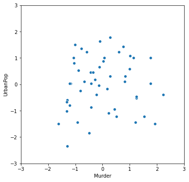

```python
import seaborn as sns
import matplotlib.pyplot as plt

arrest2_norm_2 = pd.DataFrame(arrest2_norm, columns=arrest2.columns)
plt.figure(figsize=(6, 6))
sp = sns.scatterplot('Murder', 'UrbanPop', data=arrest2_norm_2)
sp.set(xlim=(-3, 3), ylim=(-3, 3))
arrest2_norm_2.std(axis=0)
arrest2_norm_2.mean(axis=0)
```

```python
# USArrest
from sklearn.discriminant_analysis import LinearDiscriminantAnalysis as lda
lda()
```

[output not shown]